# Gene Flow Models for *Palythoa tuberculosa*

## Haplotyping

### rad_haplotyper.pl

Chris Hollenbeck has created a script that can get haplotypes from dDocent output. First, gotta remove the -RG from the .bam and .bai files.

```r
for f in *.bam; do mv "$f" "${f%-RG.bam}.bam" ; done
for f in *.bam.bai; do  mv "$f" "${f%-RG.bam.bai}.bam.bai" ; done
```

Now, to install the rad_haplotyper environment following [these](https://github.com/chollenbeck/rad_haplotyper) instructions

hmmm … rad_haplotyper isn’t working because the Vcf Perl module changed its name to VCF… breaking the script. I tried a few minor modifications but couldn’t fix it. Created an issue in the github site.

Remember to remove the environment: $ conda remove rad_haplotyper_env

### Microhaplot

I am now going to try [microhaplot](https://ngthomas.github.io/microhaplot/index.html) by Thomas Ng and Eric Anderson!!

Now, have to convert the bam files to sam files.

```r
for bam in *.bam
do
echo $bam
samtools view -h -o ../sam_files/${bam%.bam}.sam $bam
done

for bam in *.bam
do
echo $bam
mv $bam ${bam%-RG.bam}.bam
done

for bam in *.bai
do
echo $bam
mv $bam ${bam%-RG.bam.bai}.bam.bai
done

for bam in *.bam
do
echo $bam
samtools idxstats $bam > ./idxstats/${bam%.bam}_idxstats.txt
done


for bam in *.bam
do
echo $bam
samtools view -h -o /Users/edc5240/Datasets/Ptuberculosa/sam_files/${bam%.bam}.sam $bam
done
```

#### Tutorial

Do the [tutorial](https://ngthomas.github.io/microhaplot/articles/microhaplot-walkthrough.html)

```r
library(microhaplot)
shiny_dir <- "/Volumes/GoogleDrive-103325533945714033178/My Drive/Ptuberculosa/Ptuberculosa_data/shiny_dir"
microhaplot::mvShinyHaplot(shiny_dir)

app.path <- file.path(shiny_dir, "microhaplot")
microhaplot::runShinyHaplot(app.path)
```

#### Load Data

Then follow along [here](https://ngthomas.github.io/microhaplot/articles/microhaplot-data-prep.html) to get data into microhaplot.

```r
library(microhaplot)

run.label <- "Ptuberculosa"

path <- "/Users/edc5240/Datasets/Ptuberculosa"
sam.path <- "/Users/edc5240/Datasets/Ptuberculosa/sam_files"
# untar(system.file("extdata",
#                   "sebastes_sam.tar.gz",
#                   package="microhaplot"),
#       exdir = sam.path)


label.path <- file.path(path, "labels.txt")
vcf.path <- file.path(path, "mm0.9minq30mac3thin500.recode.vcf")

mvShinyHaplot(file.path(path,"shiny_dir"))
app.path <- file.path(path,"shiny_dir", "microhaplot")

haplo.read.tbl <- prepHaplotFiles(run.label = run.label,
                            sam.path = sam.path,
                            out.path = path,
                            label.path = label.path,
                            vcf.path = vcf.path,
                            app.path = app.path)

runShinyHaplot(path = "/Users/edc5240/Datasets/Ptuberculosa/shiny_dir/microhaplot")
```

Working with the data in microhaplot was OK, but I kept getting unexplained N’s in the output, and it was going to take some coding effort to translate the output into migrate format. Moreover, microhaplot only kept the variable sites, which isn’t ideal for migrate’s mutation model. So I am giving up on this front, and am going to try to generate haplotypes with Stacks.

# Haplotypes from Stacks

## Setup

Need first to copy all the fastq files over from Google Drive, where ’Ale’a put them. I split them into 4 tranches to keep the number of files under 50 as required by gdown. Note that the folder protocol won’t take urls, but just the ID.

```r
gdown --id 1ES3yMzZS8JkWROiE1jdfTp6KBjxDdCXO --folder --remaining-ok --output firstbatch
gdown --id 1Ofta4RLcf6vddIiAA6dLCkdrYngADW1d --folder --remaining-ok --output secondbatch
gdown --id 1Og6JQNlhgprYvLTxJtMBlCCj72qRxLOw --folder --remaining-ok --output thirdbatch
gdown --id 1Ojnlj3L_8UFoPUVxaqvLKTLs8qq_S9ml --folder --remaining-ok --output fourthbatch
```

Need to rename the files into Illumina format in order for Stacks to recognize the paired reads

```r
cd raw

for f in *.F.fq.gz
do
mv $f ${f/_1.F.fq.gz/_R1_001.fastq.gz}
done

for f in *.R.fq.gz
do
mv $f ${f/_1.R.fq.gz/_R2_001.fastq.gz}
done

cd ..
```

## Process RadTags

’Ale’a said:

> It was an ezRAD protocol developed by the Tobo lab. The restriction enzymes used were both MboI and Sau3AI. The sequences have indexes removed but still need to be trimmed/ends cleaned.

So I will process the radtags to remove adapters and the sau3AI cut site (GATC, which is the same as MboI). This command cleans data removing reads with uncalled bases, low phred scores, rescue barcodes and rad-tags.

```r
process_radtags -p ./raw/ -o ./cleaned/ --rescue --clean --quality --paired --filter_illumina --renz-1 sau3AI \
--adapter-1 AGATCGGAAGAGCACACGTCTGAACTCCAGTCA \
--adapter-2 AGATCGGAAGAGCGTCGTGTAGGGAAAGAGTGT
```

> 724964572 total sequences 0 failed Illumina filtered reads (0.0%) 227835784 reads contained adapter sequence (31.4%) 0 barcode not found drops (0.0%) 28941251 low quality read drops (4.0%) 63374437 RAD cutsite not found drops (8.7%) 404813100 retained reads (55.8%)

## Pipeline

Hmm… gotta rename the cleaned files too

```r
cd cleaned
for f in *001.1.fq.gz
do
mv $f ${f/_R[12]_001.1.fq.gz/.1.fq.gz}
done

for f in *001.2.fq.gz
do
mv $f ${f/_R[12]_001.2.fq.gz/.2.fq.gz}
done
```

I’m going to use the denovo_map.pl pipeline. This command will take data from `./cleaned` and the popmap I created for dDocent and -m 3 reads per stack, -n 4 distance between stacks, -M 4 distance between catalog loci. Running on 12 -T threads and only keeping loci that appear in 75% of individuals in all 10 populations

```r
denovo_map.pl --samples ./cleaned/ --popmap ../popmap --out-path ./pipeline --paired \
-m 3 -n 4 -M 4 -T 12 -r 75 -p 10 -X "populations: --fasta-samples" -X "populations: --filter-haplotype-wise"
```

Copy it down

```r
scp -r  ecrandall@128.118.123.64:eric_data/ptuberculosa/stacks/pipeline/output1 ./stacks_output
```

## Populations

Now I need to re-run `populations` to get more statistics. Original populations output is in output1, this will be in output2.

```r
populations -P ../ -O ./ -M ../../../popmap -t 12 -p 10 -r 75 -H --hwe --fstats --p-value-cutoff 0.99 --fasta-loci --fasta-samples --vcf --genepop --structure --treemix --fasta-samples-raw
```

## Fasta2Genotype

Paul Maier created [this script](http://www.mountainmanmaier.com/software/) to convert Stacks haplotypes to migrate format. I had to remove all the [individualName] tokens from the populations.samples.fa to get it to work.

```r
python2 /Applications/migrate/migrate-4.4.4/fasta2genotype/fasta2genotype.py populations.samples2.fa NA ../popmap.tsv  populations.snps.vcf ptuberculosa.mig
```

```r
###################################################################
###                                                             ###
###       Fasta2Genotype | Data Conversion | Version 1.10       ###
###                                                             ###
###                        Cite as follows:                     ###
###                                                             ###
###   Maier P.A., Vandergast A.G., Ostoja S.M., Aguilar A.,     ###
###   Bohonak A.J. (2019). Pleistocene glacial cycles drove     ###
###   lineage diversification and fusion in the Yosemite toad   ###
###   (Anaxyrus canorus). Evolution, in press.                  ###
###   https://www.doi.org/10.1111/evo.13868                     ###
###                                                             ###
###################################################################

Output type? [1] Migrate [2] Arlequin [3] DIYABC [4] LFMM [5] Phylip [6] G-Phocs [7] Treemix [8] Haplotype: 1
Remove restriction enzyme or adapter sequences? These may bias data. [1] Yes [2] No: 2
Coverage Cutoff (number reads for locus)? Use '0' to ignore coverage: 0
Remove monomorphic loci? [1] Yes [2] No: 2
Remove loci with excess heterozygosity? This can remove paralogs. [1] Yes [2] No: 1
Maximum heterozygosity cutoff for removing loci out of Hardy-Weinberg? 0.5
Filter for allele frequency? False alleles might bias data. [1] Yes [2] No: 2
Filter for missing genotypes? These might bias data. [1] Yes [2] No: 2

**************************************************************************************************************
***                                       ... BEGINNING CONVERSION ...                                     ***
**************************************************************************************************************

Cataloging loci...
Counting locus lengths...
Cataloging populations...
Counting gene copies...
Counting alleles for each locus...
Identifying loci with excess heterozygosity...
     Calculating observed heterozygosity and homozygosity...
     Calculating expected heterozygosity and homozygosity...
     Flagging loci with excess heterozygosity for removal...
     Removing loci...
     Removed 2 overly heterozygous loci.
Outputting migrate-n file...
*** DONE! ***
```

Then I manually re-ordered the populations to run from north to south in the output file, and moved it into the migrate folder.

# Migrate

## Install Migrate

Install the parallel version of Migrate on Nautilus server. I hade to remove `-fvectorize` from line 100 of the makefile to get this to work.

```r
curl https://peterbeerli.com/migrate-html5/download_version4/migrate-newest-src.tar.gz > migrate.tar.gz
tar -fvxz migrate.tar.gz
cd migrate-4.4.4/
cd src
./configure
make mpis (for parallel running)
sudo cp migrate-n-mpi /usr/local/bin/migrate-n-mpi
```

## Locus Statistics & Mutation Model

These RAD loci are much less variable than COI that I’m used to using. I need to figure out an overall mutation model to use with RAD loci. I can’t find any [discussion of this issue on the Migrate Google Group](https://groups.google.com/g/migrate-support/search?q=%22mutation%20model%22), so [I created one](https://groups.google.com/g/migrate-support/c/XjV_4jZW4RI/m/HbRWoGY6AwAJ). I guess I’ll use `modelTest` in the phangorn package to see where that gets me.

I renamed the FASTA headers in `populations.samples.fa` with BBEdit:

```r
Find: >CLocus_\d+_Sample_\d+_Locus_(\d+)_Allele_([01]) \[(.+)\]
Replace: >\3_L\1_A\2
```

Lets load in the data and calculate some statistics for each locus. Previously Migrate-n only implemented the F84 (=HKY) model, with two rates (Transistions and Transversions) and gamma distributed rate variability. The new v4 has a `datamodel` parameter that suggests it might take other models of molecular evolution, but the possible models are not listed in the documentation! So I will just fit an HKY model.

note the interface lists these possible models: 1 Jukes-Cantor model 2 Kimura 2-parameter model 3 Felsenstein 1981 (F81) model 4 Felsenstein 1984 (F84) model 5 Hasegawa-Kishino-Yano model 6 Tamura-Nei model

```r
fastadata <- read.FASTA("/Volumes/GoogleDrive-103325533945714033178/My Drive/Ptuberculosa/stacks_output/allpops75_hwe/populations.samples_rename.fasta")

# have to read in the locus lengths, because this is the only way to make sure the stats
# and the migrate infile are ordered the same
migrate_lengths <- read_lines("/Volumes/GoogleDrive-103325533945714033178/My Drive/Ptuberculosa/stacks_output/ptuberculosa.mig", skip = 1, n_max=1) %>%
  str_split("\\t", simplify = T) %>%  t(.) %>% tibble(length=.)

# Get locus names. fasta2genotype orders them alphabetically, so do this here too
locus_names <- str_extract(names(fastadata),"L\\d+") %>% unique() %>% sort()

stats <- tibble(locus = character(),
                length = numeric(),
                segSites = numeric(),
                nHaps = numeric(),
                nucDiv = numeric(),
                ttRatio = numeric(),
                model = character(),
                gammaShape = numeric(),
                rate1 = numeric(),
                rate2 = numeric(),
                rate3 = numeric(),
                rate4 = numeric(),
                Q1= numeric(),
                Q2 = numeric(),
                Q3 = numeric(),
                )

for(l in locus_names){
  print(paste("Now Doing Locus", l, match(l, locus_names), "out of", length(locus_names)))
  locus_dnabin <- fastadata[str_which(names(fastadata),pattern = l)]
  # convert to package formats
  locus_dnabin <- as.matrix(locus_dnabin)
  locus_gtypes <- sequence2gtypes(locus_dnabin)
  locus_phy <- phyDat(locus_dnabin)
  #create a haplotype network .. to be continued
  haps <- haplotype(locus_dnabin)
  nhaps <- length(dimnames(haps)[[1]])
  #tcs <- haploNet(haps)
  #find parameters of HKY (F84) model
  modeltest <- modelTest(locus_phy, model = c("JC","K80", "F81", "HKY","TrN"),
                         G = T, I = F, k = 4, mc.cores = 4)
  # pick out the best model. If multiple models are tied for best, pick the simplest one
  bestmodel <- modeltest$Model[which(modeltest$BIC == min(modeltest$BIC))][1]
  #open the object environment
  env <- attr(modeltest,"env")
  bestparams <- get(bestmodel, env)
  bestparams <- eval(bestparams, env=env)
  # use this code for v3, which only has F84 (HKY)
  #HKY <- modelTest(locus_phy, model = c("HKY"),
  #                       G = T, I = F, k = 4)
  #env <- attr(HKY, "env")
  #HKYG <- get("HKY+G", env)
  #model <- eval(HKYG, env=env)
  # calculate TiTv Ratio
  ttratio <- TiTvRatio(locus_gtypes)

  stats <- bind_rows(stats, tibble(locus=l,
                          length = length(locus_dnabin[1,]),
                          segSites = length(seg.sites(locus_dnabin)),
                          nHaps = length(dimnames(haps)[[1]]),
                          nucDiv = nuc.div(locus_dnabin),
                          ttRatio =  ttratio[3],
                          model = bestmodel,
                          gammaShape = bestparams$shape,
                          rate1 = bestparams$g[1],
                          rate2 = bestparams$g[2],
                          rate3 = bestparams$g[3],
                          rate4 = bestparams$g[4],
                          Q1 = sort(unique(bestparams$Q))[1],
                          Q2 = sort(unique(bestparams$Q))[2],
                          Q3 = sort(unique(bestparams$Q))[3]
                          ))


}

stats <- stats[which(stats$length %in% migrate_lengths$length),]
#setdiff(stats$length, as.numeric(migrate_lengths$length))
# write_csv(stats, "./migrate/run4_locus_statistics.csv")
```

## Write a model block

Write a space delimited textfile that can be added to the migrate data file in the format that Peter suggested.

```r
stats <- read_csv("./migrate/run4_locus_statistics.csv")
kable(stats)


# write a space delimited textfile that can be added to the migrate data file
# following Peter's suggestion here:
#https://groups.google.com/g/migrate-support/c/XjV_4jZW4RI/m/HbRWoGY6AwAJ
migrate_mutation_models <- tibble(prefix = "#$",
                                 locus=1:length(stats$locus),
                                 type = "s",
                                 model = stats$model,
                                 q1 = stats$Q2,
                                 q2 = stats$Q3)

#write_delim(migrate_mutation_models,"./migrate/run4_modelblock.txt", na="", delim = " ")
```

Read them back in so we don’t have to recalculate them every time I knit.

```r
stats <- read_csv("./migrate/run4_locus_statistics.csv")
kable(stats)
```

| locus | length | segSites | nHaps | nucDiv | ttRatio | model | gammaShape | rate1 | rate2 | rate3 | rate4 | Q1 | Q2 | Q3 |
| --- | --- | --- | --- | --- | --- | --- | --- | --- | --- | --- | --- | --- | --- | --- |
| L10061 | 411 | 1 | 2 | 0.0000280 | Inf | F81 | 1 | 1 | NA | NA | NA | 1 | NA | NA |
| L1096075 | 388 | 7 | 8 | 0.0002340 | 6.0000000 | K80 | 1 | 1 | NA | NA | NA | 1 | 12.02642 | NA |
| L11008 | 472 | 2 | 6 | 0.0000000 | 1.0000000 | JC | 1 | 1 | NA | NA | NA | 1 | NA | NA |
| L11074 | 468 | 2 | 3 | 0.0000491 | 0.0000000 | JC | 1 | 1 | NA | NA | NA | 1 | NA | NA |
| L11315 | 499 | 4 | 5 | 0.0001620 | 1.0000000 | F81 | 1 | 1 | NA | NA | NA | 1 | NA | NA |
| L11796 | 516 | 1 | 2 | 0.0000239 | Inf | F81 | 1 | 1 | NA | NA | NA | 1 | NA | NA |
| L1180 | 496 | 5 | 6 | 0.0001581 | 1.5000000 | F81 | 1 | 1 | NA | NA | NA | 1 | NA | NA |
| L12220 | 337 | 2 | 4 | 0.0000346 | Inf | F81 | 1 | 1 | NA | NA | NA | 1 | NA | NA |
| L1257 | 512 | 3 | 9 | 0.0000000 | 0.5000000 | JC | 1 | 1 | NA | NA | NA | 1 | NA | NA |
| L12728 | 618 | 1 | 2 | 0.0000180 | 0.0000000 | JC | 1 | 1 | NA | NA | NA | 1 | NA | NA |
| L13246 | 387 | 2 | 3 | 0.0001455 | 0.0000000 | JC | 1 | 1 | NA | NA | NA | 1 | NA | NA |
| L1334 | 394 | 3 | 6 | 0.0000287 | 2.0000000 | JC | 1 | 1 | NA | NA | NA | 1 | NA | NA |
| L13955 | 500 | 4 | 5 | 0.0000460 | 0.3333333 | F81 | 1 | 1 | NA | NA | NA | 1 | NA | NA |
| L14063 | 726 | 0 | 1 | 0.0000000 | NA | JC | 1 | 1 | NA | NA | NA | 1 | NA | NA |
| L14455 | 479 | 2 | 3 | 0.0000491 | 1.0000000 | JC | 1 | 1 | NA | NA | NA | 1 | NA | NA |
| L14518 | 338 | 2 | 2 | 0.0000688 | 1.0000000 | F81 | 1 | 1 | NA | NA | NA | 1 | NA | NA |
| L14522 | 382 | 2 | 4 | 0.0000302 | Inf | F81 | 1 | 1 | NA | NA | NA | 1 | NA | NA |
| L14706 | 316 | 4 | 5 | 0.0001836 | 3.0000000 | JC | 1 | 1 | NA | NA | NA | 1 | NA | NA |
| L14759 | 659 | 0 | 1 | 0.0000000 | NA | F81 | 1 | 1 | NA | NA | NA | 1 | NA | NA |
| L14943 | 478 | 2 | 3 | 0.0000481 | 1.0000000 | JC | 1 | 1 | NA | NA | NA | 1 | NA | NA |
| L1558 | 446 | 5 | 4 | 0.0001437 | 1.5000000 | JC | 1 | 1 | NA | NA | NA | 1 | NA | NA |
| L15879 | 353 | 11 | 10 | 0.0003399 | 0.5714286 | F81 | 1 | 1 | NA | NA | NA | 1 | NA | NA |
| L16369 | 397 | 1 | 2 | 0.0000303 | 0.0000000 | F81 | 1 | 1 | NA | NA | NA | 1 | NA | NA |
| L17180 | 729 | 3 | 4 | 0.0000473 | 0.5000000 | JC | 1 | 1 | NA | NA | NA | 1 | NA | NA |
| L1747065 | 269 | 0 | 1 | 0.0000000 | NA | JC | 1 | 1 | NA | NA | NA | 1 | NA | NA |
| L18283 | 413 | 2 | 4 | 0.0000279 | 1.0000000 | F81 | 1 | 1 | NA | NA | NA | 1 | NA | NA |
| L18719 | 463 | 5 | 7 | 0.0001285 | 1.5000000 | F81 | 1 | 1 | NA | NA | NA | 1 | NA | NA |
| L1875 | 741 | 1 | 3 | 0.0000000 | Inf | F81 | 1 | 1 | NA | NA | NA | 1 | NA | NA |
| L19311 | 701 | 1 | 3 | 0.0000000 | 0.0000000 | F81 | 1 | 1 | NA | NA | NA | 1 | NA | NA |
| L19853 | 370 | 1 | 3 | 0.0000000 | 0.0000000 | F81 | 1 | 1 | NA | NA | NA | 1 | NA | NA |

[output cut: 79 more lines]

```r
# write a space delimited textfile that can be added to the migrate data file
# following Peter's suggestion here:
#https://groups.google.com/g/migrate-support/c/XjV_4jZW4RI/m/HbRWoGY6AwAJ
migrate_mutation_models <- tibble(prefix = "#$",
                                 locus=1:length(stats$locus),
                                 type = "s",
                                 model = stats$model,
                                 q1 = stats$Q2,
                                 q2 = stats$Q3)

#write_delim(migrate_mutation_models,"./migrate/run4_modelblock.txt", na="", delim = " ")
```

So we have a 16 invariant loci, and the mean overall transition:transversion ratio is 0.7927928. Mean gamma shape parameter is 765.8643026, which argues for only one rate.

## Parmfile

I went through and compared my 3.x parmfile line by line to the default one generated by Migrate 4.4.4, and came up with this

```r
################################################################################
# Parmfile for Migrate 4.4.4(git:v4-series-26-ge85c6ff)-June-1-2019 [do not remove these first TWO lines]
# generated automatically on
# Sat Jan 15 14:10:36 2022
#
# please report problems to Peter Beerli
#  email: beerli@fsu.edu
#  http://popgen.sc.fsu.edu/migrate.html
menu=YES
nmlength=10
datatype=SequenceData
datamodel=HKY
ttratio=1.000000

freqs-from-data=YES

# data were filtered to Q30, so this seems like a good seqerror
seqerror-rate={0.0001,0.0001,0.0001,0.0001}
categories=1 #no categories file specified
rates=1: 1.000000
prob-rates=1: 1.000000
autocorrelation=NO
weights=NO
recover=NO
fast-likelihood=NO
inheritance-scalars={1.00000000000000000000}
haplotyping=YES:no-report
population-relabel={1 2 3 4 5 6 7 8 9 10}
infile=../../ptuberculosa.mig
random-seed=AUTO #OWN:410568459
title= Palythoa tuberculosa - Hawaii

progress=YES

logfile=NO

print-data=NO

outfile=outfile.txt

pdf-outfile=outfile.pdf

pdf-terse=NO

use-M=YES

print-tree=NONE

mig-histogram=NO
skyline=NO #needs mig-histogram=ALL:...

theta=PRIOR:50
migration=PRIOR:10
rate=PRIOR:50
split=PRIOR:10
splitstd=PRIOR:10

mutation=CONSTANT

analyze-loci=A

divergence-distrib=S

#standard stepping-stone model for starters
custom-migration={
**00000000
***0000000
0***000000
00***00000
000***0000
0000***000
00000***00
000000***0
0000000***
00000000**
}

geo=NO

updatefreq=0.200000 0.200000 0.200000 0.200000 #tree, parameter haplotype, timeparam updates
bayes-posteriorbins= 500 500
bayes-posteriormaxtype=TOTAL
bayes-file=YES:bayesfile
bayes-allfile=YES:bayesallfile
bayes-all-posteriors=YES:bayesallposterior
bayes-proposals= THETA METROPOLIS-HASTINGS Sampler
bayes-proposals= MIG SLICE Sampler
bayes-proposals= DIVERGENCE METROPOLIS-HASTINGS Sampler
bayes-proposals= DIVERGENCESTD METROPOLIS-HASTINGS Sampler
bayes-priors= THETA WEXPPRIOR: 0.0 0.01 0.1000000 0.01000
bayes-priors= MIG WEXPPRIOR: 0.000100 100000.000000 1000000
bayes-priors= RATE * * UNIFORMPRIOR: 0.000000 10000000000.000000 1000000000.000000
bayes-hyperpriors=NO
#
long-chains=1
long-inc=100
long-sample=10000
burn-in=2000
auto-tune=YES:0.440000
assign=NO

heating=YES:1:{1.000000,1.500000,3.000000,1000000.000000}
heated-swap=YES

moving-steps=NO

gelman-convergence=No

replicate=NO

end
```

## Test Run 1

Let’s see what happens! Started this run on Jan 22, at 10pm.

```r
screen -S migrate_testrun

mpirun -np 32 ~/migrate-4.4.4/src/migrate-n-mpi parmfile
```

And it was finished the next morning! Prior on m was too wide, giving results like this:

### Results

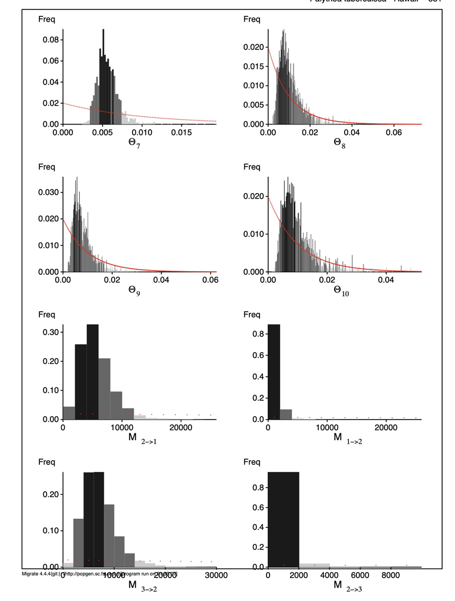

No bueno.

## Test Run 2

### Revise m prior

Revised the m prior like so (I had no window value in the original!) Order of values is min, mean, maximum, proposal window.

```r
bayes-priors= MIG WEXPPRIOR: 0.000100 1000.000000 10000 100
```

### Panmixia

A few modifications to make a panmictic model

```r
population-relabel={1 1 1 1 1 1 1 1 1 1}
#and
custom-migration={
*
}
```

### Island Model

Change all parameter values to m for island model.

```r
custom-migration={
mmmmmmmmmm
mmmmmmmmmm
mmmmmmmmmm
mmmmmmmmmm
mmmmmmmmmm
mmmmmmmmmm
mmmmmmmmmm
mmmmmmmmmm
mmmmmmmmmm
mmmmmmmmmm
}
```

Minor github issue. Got a little hung up at this point because I accidentally committed some bayesallfiles that were hundreds of Mb, and of course github wouldn’t let me upload those. Thought I fixed it with [these instructions](https://stackoverflow.com/questions/12481639/remove-files-from-git-commit). Then ended up trying [git-filter-repo](https://htmlpreview.github.io/?https://github.com/newren/git-filter-repo/blob/docs/html/git-filter-repo.html) (installed via homebrew), then ended up restoring the whole thing from the github repository. Ouch. Then it wouldn’t push until I ran `git prune`

### Results

#### Model Selection

Very nice! 😃 Going to need to modify my code to read multilocus output from migrate-n.

```r
workingDir <- "./migrate/run2"

modelMarglikes <- harvest.model.likelihoods(workingDir = workingDir)
```

```
[1] "./migrate/run2/island"
```

```
Read 1900 items
```

```
[1] "./migrate/run2/panmixia"
```

```
Read 1774 items
```

```
[1] "./migrate/run2/stepping.stone"
```

```
Read 4829 items
```

```r
kable(modelMarglikes, format.args = list(digits = 5))
```

| model | thermodynamic | bezier.corrected | harmonic |
| --- | --- | --- | --- |
| island | -71972 | -71120 | -71813 |
| panmixia | -70400 | -69492 | -69655 |
| stepping.stone | -65995 | -65136 | -65790 |

```r
results <- bfcalcs(modelMarglikes)

kable(results)
```

| model | thermodynamic | bezier.corrected | harmonic | lbf | choice | modelprob |
| --- | --- | --- | --- | --- | --- | --- |
| island | -71971.81 | -71120.19 | -71812.53 | -11967.82 | 3 | 0 |
| panmixia | -70400.30 | -69492.18 | -69654.60 | -8711.80 | 2 | 0 |
| stepping.stone | -65995.43 | -65136.28 | -65789.54 | 0.00 | 1 | 1 |

#### Parameters

```r
workingDir2 <- "/Volumes/GoogleDrive-103325533945714033178/My Drive/Ptuberculosa/stacks_output/migrate/testrun/run2"

winningModelDir <- file.path(workingDir2, "stepping.stone")

#this may take a minute or two
data <- read.table(file.path(winningModelDir,"bayesallfile"), header=T)

#calculate migrants per generation
data.nm <- migrants.per.gen(data)

data %>% group_by(locus) %>% summarize()
# Split the whole list into the individual replicates, so that you will
# have a list of data frames
#data.list.1 <- split(data.nm,data$Replicate)

#split the data on locus
data.list.1 <- split(data.nm,data$Locus)
data.list.mcmc <- mcmc.list(lapply(data.list.1,mcmc))
# Remove burnin if it wasn't removed in the run, where burnin is a proportion of the total.
# e.g. First 40% First 20,000 samples out of 50,000 or 10 million steps out of 25 million
#burnin <- 0.2
#data.list.1<-lapply(data.list.1,subset,subset=Steps>(burnin*max(data.list.1[[1]]$Steps)))

data.list.mcmc <- mcmc.list(data.list.1)

#convert each dataframe to an mcmc object and then convert the whole thing to an mcmc list

#collapse all replicates to one for purposes of highest posterior density
data.list.allinone <- mcmc(data=do.call("rbind",data.list.2))


summ <- summary(data.list.mcmc)
ess <- effectiveSize(data.list.mcmc)
gelman <- gelman.diag(data.list.mcmc,multivariate=F)
HPD <- HPDinterval(data.list.allinone)

#concatenate the stats
allstats<-cbind(summ$statistics[,1:2],HPD,ess,gelman$psrf)
#write.csv(allstats,file="codastats.csv")
```

## First Analysis Run

’Ale’a and I settled on the following models

### Models

```r
#Panmixia (panmixia; 1 panmictic population)
population-relabel={1 1 1 1 1 1 1 1 1 1}
custom-migration=   *





#n-Island (island; all populations same size, all exchange migrants)
population-relabel={1 2 3 4 5 6 7 8 9}
custom-migration=
  Pop_Kure                  m   m   m   m   m   m   m
    Pop_P&H                   m m   m   m   m   m   m
    Pop_MaroReef                m   m   m   m   m   m   m
    Pop_FFS                   m m   m   m   m   m   m
    Pop_Kauai                   m   m   m   m   m   m   m
    Pop_Oahu                    m   m   m   m   m   m   m
    Pop_Molokai               m m   m   m   m   m   m
    Pop_Maui                    m   m   m   m   m   m   m
    Pop_BigIsland               m   m   m   m   m   m   m






#Stepping-Stone (stepping.stone)
population-relabel={1 2 3 4 5 6 7 8 9}
    Pop_Kure                    *   *   0   0   0   0   0   0   0
    Pop_P&H                     *   *   0   0   0   0   0   0   0
    Pop_MaroReef                0   *   *   *   0   0   0   0   0
    Pop_FFS                     0   0   *   *   *   0   0   0   0
    Pop_Kauai                   0   0   0   *   *   *   0   0   0
    Pop_Oahu                    0   0   0   0   *   *   *   0   0
    Pop_Molokai                 0   0   0   0   0   *   *   *   0
    Pop_Maui                    0   0   0   0   0   0   *   *   *
    Pop_BigIsland               0   0   0   0   0   0   0   *   *





#Stepping-Stone with a Kure-Oahu connection (stepping.stone.KO)
population-relabel={1 2 3 4 5 1 7 8 9}
custom-migration=
    Pop_Kure                    *   *   0   0   0   0   *   0   0
    Pop_P&H                     *   *   0   0   0   0   0   0   0
    Pop_MaroReef                0   *   *   *   0   0   0   0   0
    Pop_FFS                     0   0   *   *   *   0   0   0   0
    Pop_Kauai                   0   0   0   *   *   *   0   0   0
    Pop_Oahu                    *   0   0   0   *   *   *   0   0
    Pop_Molokai                 0   0   0   0   0   *   *   *   0
    Pop_Maui                    0   0   0   0   0   0   *   *   *
    Pop_BigIsland               0   0   0   0   0   0   0   *   *




#NWHI vs MHI    (NWHI_MHI; two panmictic regions)
population-relabel={1 1 1 1 2 2 2 2 2}
custom-migration=
  Pop_NWHI                  *   *
    Pop_MHI                   * *




# Stepping Stone Breaks (stepping.stones.breaks;
#  regional groups of Kure_PH vs MR_FFS vs MHI as lumped populations
#  with stepping stone gene flow between them. )
population-relabel={1 1 2 2 3 4 5 6 7}
custom-migration=
  Pop_Kure_PH                   *   *   0   0   0   0   0
    Pop_MaroReef_FFS                *   *   *   0   0   0   0
    Pop_Kauai                       0   *   *   *   0   0   0
    Pop_Oahu                        0   0   *   *   *   0   0
    Pop_Molokai                   0 0   0   *   *   *   0
    Pop_Maui                        0   0   0   0   *   *   *
    Pop_BigIsland                   0   0   0   0   0   *   *



# Stepping Stone Breaks (stepping.stones.breaks;
#  regional groups of Kure_PH vs MR_FFS vs MHI as lumped populations
#  with stepping stone gene flow between them, and a Kure-Oahu connection.)
population-relabel={1 1 2 2 3 4 5 6 7}
custom-migration=
  Pop_Kure_PH                   *   *   0   *   0   0   0
    Pop_MaroReef_FFS                *   *   *   0   0   0   0
    Pop_Kauai                       0   *   *   *   0   0   0
    Pop_Oahu                        *   0   *   *   *   0   0
    Pop_Molokai                   0 0   0   *   *   *   0
    Pop_Maui                        0   0   0   0   *   *   *
    Pop_BigIsland                   0   0   0   0   0   *   *
```

I also turned menu = NO, and replicate=YES:3.

### Bash Script

So we will do 10 replicates of 3 replicates. This will start at r1, and run all models for that before moving on. Pretty sure this will finish one whole model before moving on to the next one (since all threads are being used for different loci)

```r
#!
for r in */
    do
        cd $r
        echo $r
        date
        date > date.txt
            for m in */
              do
                cd $m
                  date > date.txt
                  echo $m
                  date
                  mpirun -np 32 ~/migrate-4.4.4/src/migrate-n-mpi parmfile
                  sleep 1
                cd ..
              done
        cd ..
    done
```

### Copy It Up

Copy it up, and then make a total of 10 replicate copies of the folder.

```r
scp -r ./run4 ecrandall@nautilus.psu.edu:./Ptuberculosa/run4/r1

#once on server, copy it 9 times
for a in $(seq 2 10); do cp -r rep1 rep$a; done
```

### And back down

And ten replicates finished in about 10 days! Found [this guide](https://www.cyberciti.biz/faq/scp-exclude-files-when-using-command-recursively-on-unix-linux/) to download everything except the massive bayesallfiles and pdfs

```r
rsync -av -e ssh --exclude='bayes*' --exclude="*.pdf"  ecrandall@nautilus.psu.edu:~/Ptuberculosa/run4 ./

rsync -av -e ssh --exclude='bayes*'  ecrandall@nautilus.psu.edu:~/Ptuberculosa/run4/rep1/stepping.stone.all ./stepping.stone.KO.all
```

### Results

#### Model Marginal Likelihoods

```r
runDir <- "/Volumes/GoogleDrive/My Drive/ptuberculosa/migrate/run4"
#runDir <-"/Volumes/GoogleDrive-103325533945714033178/My Drive/ptuberculosa/migrate/run4"

likelist <- list()
for(r in 1:10){
  rep = paste0("rep",r)
  print(rep)
  likelist[[rep]] <- harvest.model.likelihoods(workingDir=file.path(runDir,rep))
}
```

```r
# Model selection for each replicate...
likelist %>% map(bfcalcs)
```

| model | thermodynamic | bezier.corrected | harmonic | lbf | choice | modelprob |
| --- | --- | --- | --- | --- | --- | --- |
| island | -85392.22 | -75324.81 | -73603.96 | -12245.92 | 7 | 0 |
| NWHI_MHI | -78518.01 | -72353.76 | -70825.42 | -6303.82 | 5 | 0 |
| panmixia | -76415.73 | -72178.77 | -70961.90 | -5953.84 | 4 | 0 |
| stepping.stone | -85009.03 | -74954.04 | -73639.51 | -11504.38 | 6 | 0 |
| stepping.stone.breaks | -80881.53 | -71116.61 | -69422.04 | -3829.52 | 3 | 0 |
| stepping.stone.breaks.KO | -79925.36 | -70322.35 | -68561.41 | -2241.00 | 2 | 0 |
| stepping.stone.KO | -79146.56 | -69201.85 | -67505.51 | 0.00 | 1 | 1 |

| model | thermodynamic | bezier.corrected | harmonic | lbf | choice | modelprob |
| --- | --- | --- | --- | --- | --- | --- |
| island | -85367.35 | -75281.08 | -73621.95 | -12069.42 | 7 | 0 |
| NWHI_MHI | -78095.58 | -72245.96 | -70842.15 | -5999.18 | 5 | 0 |
| panmixia | -76330.54 | -72179.04 | -71008.11 | -5865.34 | 4 | 0 |
| stepping.stone | -85015.33 | -75009.57 | -73595.00 | -11526.40 | 6 | 0 |
| stepping.stone.breaks | -80816.99 | -71060.30 | -69663.40 | -3627.86 | 3 | 0 |
| stepping.stone.breaks.KO | -79974.76 | -70330.04 | -68588.16 | -2167.34 | 2 | 0 |
| stepping.stone.KO | -79224.95 | -69246.37 | -67687.55 | 0.00 | 1 | 1 |

| model | thermodynamic | bezier.corrected | harmonic | lbf | choice | modelprob |
| --- | --- | --- | --- | --- | --- | --- |
| island | -85304.53 | -75274.86 | -73628.05 | -12081.96 | 7 | 0 |
| NWHI_MHI | -78209.97 | -72296.65 | -70940.36 | -6125.54 | 5 | 0 |
| panmixia | -76379.72 | -72186.14 | -70985.35 | -5904.52 | 4 | 0 |
| stepping.stone | -85024.39 | -74948.87 | -73547.46 | -11429.98 | 6 | 0 |
| stepping.stone.breaks | -80782.91 | -71046.11 | -69408.17 | -3624.46 | 3 | 0 |
| stepping.stone.breaks.KO | -79954.19 | -70295.17 | -68685.55 | -2122.58 | 2 | 0 |
| stepping.stone.KO | -79204.11 | -69233.88 | -67735.30 | 0.00 | 1 | 1 |

| model | thermodynamic | bezier.corrected | harmonic | lbf | choice | modelprob |
| --- | --- | --- | --- | --- | --- | --- |
| island | -85374.05 | -75321.43 | -73568.65 | -12144.32 | 7 | 0 |
| NWHI_MHI | -78185.50 | -72265.66 | -70785.66 | -6032.78 | 5 | 0 |
| panmixia | -76416.35 | -72173.44 | -71025.98 | -5848.34 | 4 | 0 |
| stepping.stone | -85052.45 | -74949.09 | -73609.52 | -11399.64 | 6 | 0 |
| stepping.stone.breaks | -80937.73 | -71150.86 | -69507.55 | -3803.18 | 3 | 0 |
| stepping.stone.breaks.KO | -79882.22 | -70299.65 | -68658.77 | -2100.76 | 2 | 0 |
| stepping.stone.KO | -79221.27 | -69249.27 | -67588.17 | 0.00 | 1 | 1 |

| model | thermodynamic | bezier.corrected | harmonic | lbf | choice | modelprob |
| --- | --- | --- | --- | --- | --- | --- |
| island | -85398.99 | -75297.40 | -73680.78 | -12109.82 | 7 | 0 |
| NWHI_MHI | -78148.27 | -72240.00 | -70872.98 | -5995.02 | 5 | 0 |
| panmixia | -76362.14 | -72174.81 | -71039.96 | -5864.64 | 4 | 0 |
| stepping.stone | -85010.59 | -74962.35 | -73431.78 | -11439.72 | 6 | 0 |
| stepping.stone.breaks | -80868.22 | -71081.77 | -69636.36 | -3678.56 | 3 | 0 |
| stepping.stone.breaks.KO | -79926.41 | -70302.42 | -68707.63 | -2119.86 | 2 | 0 |
| stepping.stone.KO | -79215.32 | -69242.49 | -67815.84 | 0.00 | 1 | 1 |

| model | thermodynamic | bezier.corrected | harmonic | lbf | choice | modelprob |
| --- | --- | --- | --- | --- | --- | --- |
| island | -85410.51 | -75342.72 | -73588.48 | -12077.06 | 7 | 0 |
| NWHI_MHI | -78217.12 | -72268.12 | -70890.58 | -5927.86 | 5 | 0 |
| panmixia | -76289.04 | -72177.59 | -70961.00 | -5746.80 | 4 | 0 |
| stepping.stone | -85029.66 | -74984.51 | -73675.63 | -11360.64 | 6 | 0 |
| stepping.stone.breaks | -80971.74 | -71163.71 | -69600.81 | -3719.04 | 3 | 0 |
| stepping.stone.breaks.KO | -79901.56 | -70304.31 | -68564.19 | -2000.24 | 2 | 0 |
| stepping.stone.KO | -79310.06 | -69304.19 | -67830.15 | 0.00 | 1 | 1 |

| model | thermodynamic | bezier.corrected | harmonic | lbf | choice | modelprob |
| --- | --- | --- | --- | --- | --- | --- |
| island | -85404.07 | -75306.16 | -73728.19 | -11997.94 | 7 | 0 |
| NWHI_MHI | -78044.54 | -72253.50 | -70888.74 | -5892.62 | 5 | 0 |
| panmixia | -76286.00 | -72157.60 | -71002.48 | -5700.82 | 4 | 0 |
| stepping.stone | -84964.98 | -74867.72 | -73436.09 | -11121.06 | 6 | 0 |
| stepping.stone.breaks | -80875.81 | -71125.14 | -69550.37 | -3635.90 | 3 | 0 |
| stepping.stone.breaks.KO | -79891.65 | -70272.36 | -68632.01 | -1930.34 | 2 | 0 |
| stepping.stone.KO | -79246.94 | -69307.19 | -67758.83 | 0.00 | 1 | 1 |

| model | thermodynamic | bezier.corrected | harmonic | lbf | choice | modelprob |
| --- | --- | --- | --- | --- | --- | --- |
| island | -85393.61 | -75315.33 | -73595.58 | -12126.58 | 7 | 0 |
| NWHI_MHI | -78371.86 | -72317.77 | -70853.38 | -6131.46 | 5 | 0 |
| panmixia | -76313.94 | -72156.87 | -71069.04 | -5809.66 | 4 | 0 |
| stepping.stone | -84984.77 | -74930.62 | -73430.67 | -11357.16 | 6 | 0 |
| stepping.stone.breaks | -80915.98 | -71150.85 | -69549.47 | -3797.62 | 3 | 0 |
| stepping.stone.breaks.KO | -79926.80 | -70312.98 | -68721.23 | -2121.88 | 2 | 0 |
| stepping.stone.KO | -79234.83 | -69252.04 | -67863.35 | 0.00 | 1 | 1 |

| model | thermodynamic | bezier.corrected | harmonic | lbf | choice | modelprob |
| --- | --- | --- | --- | --- | --- | --- |
| island | -85432.42 | -75321.04 | -73698.54 | -12178.86 | 7 | 0 |
| NWHI_MHI | -78214.67 | -72292.73 | -70866.55 | -6122.24 | 5 | 0 |
| panmixia | -76325.27 | -72189.92 | -71006.10 | -5916.62 | 4 | 0 |
| stepping.stone | -84985.02 | -74907.66 | -73367.24 | -11352.10 | 6 | 0 |
| stepping.stone.breaks | -80805.14 | -71107.91 | -69528.68 | -3752.60 | 3 | 0 |
| stepping.stone.breaks.KO | -79964.05 | -70330.17 | -68655.61 | -2197.12 | 2 | 0 |
| stepping.stone.KO | -79198.08 | -69231.61 | -67898.54 | 0.00 | 1 | 1 |

| model | thermodynamic | bezier.corrected | harmonic | lbf | choice | modelprob |
| --- | --- | --- | --- | --- | --- | --- |
| island | -85433.77 | -75333.23 | -73639.17 | -12114.06 | 7 | 0 |
| NWHI_MHI | -78179.99 | -72278.81 | -70766.42 | -6005.22 | 5 | 0 |
| panmixia | -76294.58 | -72154.57 | -70957.90 | -5756.74 | 4 | 0 |
| stepping.stone | -84959.22 | -74891.96 | -73646.41 | -11231.52 | 6 | 0 |
| stepping.stone.breaks | -80841.54 | -71099.05 | -69435.04 | -3645.70 | 3 | 0 |
| stepping.stone.breaks.KO | -79909.71 | -70302.25 | -68707.41 | -2052.10 | 2 | 0 |
| stepping.stone.KO | -79268.56 | -69276.20 | -67704.69 | 0.00 | 1 | 1 |

```r
like.df <-  likelist %>% bind_rows() %>% group_by(model)

means <- like.df %>% summarize(bezier.corrected = mean(bezier.corrected))


final_model <- bfcalcs(means)

final_model
```

#### T-Test

```r
top.choice <- final_model$model[which(final_model$choice ==1)]
second.choice <- final_model$model[which(final_model$choice ==2)]

permTS(like.df$bezier.corrected[which(like.df$model == top.choice)],
       like.df$bezier.corrected[which(like.df$model == second.choice)],
       alternative = "greater", method = "exact.ce")
```

```r
top.choice <- final_model$model[which(final_model$choice ==1)]
second.choice <- final_model$model[which(final_model$choice ==2)]

permTS(like.df$bezier.corrected[which(like.df$model == top.choice)],
       like.df$bezier.corrected[which(like.df$model == second.choice)],
       alternative = "greater", method = "exact.ce")
```

```
    Exact Permutation Test (complete enumeration)

data:  GROUP 1 and GROUP 2
p-value = 5.413e-06
alternative hypothesis: true mean GROUP 1 - mean GROUP 2 is greater than 0
sample estimates:
mean GROUP 1 - mean GROUP 2
                   1052.661
```

#### Gene Flow between Oahu and Kure

There is an intriguing result of nearly one-way gene flow from Oahu to Kure. Also, the stepping.stone.breaks.KO is much better than just stepping.stone.breaks. This suggests that a divergence parameter for these two populations is in order.

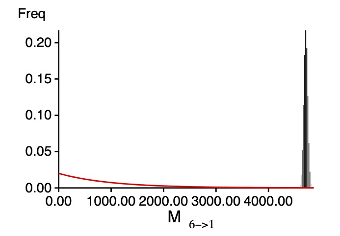

Gene Flow from Oahu to Kure

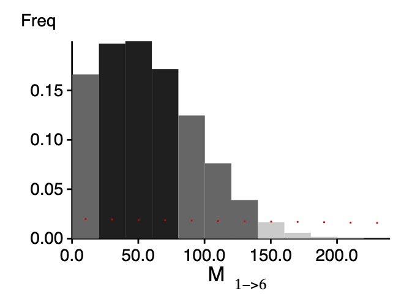

Gene Flow from Kure to Oahu

## What about one way gene flow?

Stepping.stone.KO.oneway

```
#Stepping-Stone with a *one way* Kure-Oahu ongoing gene flow connection
# (stepping.stone.KO.oneway)
population-relabel={1 2 3 4 5 1 7 8 9}
custom-migration={
*   *   0   0   0   *   0   0   0
*   *   *   0   0   0   0   0   0
0   *   *   *   0   0   0   0   0
0   0   *   *   *   0   0   0   0
0   0   0   *   *   *   0   0   0
*   0   0   0   *   *   *   0   0
0   0   0   0   0   *   *   *   0
0   0   0   0   0   0   *   *   *
0   0   0   0   0   0   0   *   *
}
```

### More Replicates

Going to add more replicates of stepping.stone.KO and stepping.stone.KO.oneway

```r
for a in $(seq 12 30); do cp -r rep11 rep$a; done
```

### Copy It Down

```r
rsync -av -e ssh --exclude='bayes*' --exclude="*.pdf"  ecrandall@nautilus.psu.edu:~/Ptuberculosa/run4.2 ./
```

### Results

#### Model Marginal Likelihoods

```r
likelist <- list()
for(r in 1:30){
  rep = paste0("rep",r)
  print(rep)
  likelist[[rep]] <- harvest.model.likelihoods(workingDir=file.path(runDir,rep))
}
```

```r
like.df <-  likelist %>% bind_rows() %>% group_by(model)

means <- like.df %>% summarize(bezier.corrected = mean(bezier.corrected))


final_model <- bfcalcs(means)

final_model
```

#### T-Test

```r
like.df <-  likelist %>% bind_rows() %>% group_by(model)

means <- like.df %>% summarize(bezier.corrected = mean(bezier.corrected))


final_model <- bfcalcs(means)

final_model
```

[output not shown]

```r
NA
```

#### Figures

```r
top.choice <- final_model$model[which(final_model$choice ==1)]
second.choice <- final_model$model[which(final_model$choice ==2)]
#third.choice <- final_model$model[which(final_model$choice ==3)]

#TS <- permTS(like.df$bezier.corrected[which(like.df$model == top.choice)],
#       like.df$bezier.corrected[which(like.df$model == second.choice)],
#       alternative = "greater")
#TS
```

```r
models <- c("N-Island", "NWHI vs. MHI"," Panmixia", "Stepping-Stone: Islands","Stepping-Stone: Regional Breaks", "Stepping-Stone: Regional Breaks, KO", "SteppingStone: Islands, KO", "Stepping-Stone: KO, OneWay")

likesPlot <- likelist %>% bind_rows() %>% group_by(model) %>%
              ggplot(mapping = aes(x=model, y = bezier.corrected)) +
              geom_violin(draw_quantiles = 0.5) +
              theme(axis.text.x = element_text(angle = 90, vjust = 0.5, hjust=1)) +
              scale_x_discrete(labels = models) +
              labs(x = "Metapopulation Model", y = "Bezier Corrected Marginal Likelihood")
likesPlot
```

[output not shown]

## Adding divergence models

[Peter says you **can** mix * with d parameters](https://groups.google.com/g/migrate-support/c/49njPlwp62E/m/xzy4DkU9AwAJ), and I tested it and it worked! Based on these results I’m going to add a model of one way ongoing migration from Oahu to Kure, and another model of divergence from Oahu to Kure about 80 years ago with no subsequent gene flow, and finally, divergence plus migration between Oahu to Kure.

### stepping.stone.KO.D

Equilibrium Gene Flow, but divergence with gene flow from Oahu to Kure

```
#Stepping-Stone with a *one way* Kure-Oahu divergence with gene flow
# (stepping.stone.KO.divmig)
population-relabel={1 2 3 4 5 1 7 8 9}
custom-migration=
    Pop_Kure                    *   0   0   0   0   0   D   0   0
    Pop_P&H                   0 *   0   0   0   0   0   0   0
    Pop_MaroReef                0   *   *   *   0   0   0   0   0
    Pop_FFS                   0 0   *   *   *   0   0   0   0
    Pop_Kauai                   0   0   0   *   *   *   0   0   0
    Pop_Oahu                    0   0   0   0   *   *   *   0   0
    Pop_Molokai               0 0   0   0   0   *   *   *   0
    Pop_Maui                    0   0   0   0   0   0   *   *   *
    Pop_BigIsland               0   0   0   0   0   0   0   *   *
```

### stepping.stone.KOd

Equilibrium Gene Flow, but divergence without gene flow from Oahu to Kure

```
#Stepping-Stone with a *one way* Kure-Oahu divergence without gene flow
# (stepping.stone.KO.div)
population-relabel={1 2 3 4 5 1 7 8 9}
custom-migration=
    Pop_Kure                    *   0   0   0   0   0   d   0   0
    Pop_P&H                   0 *   0   0   0   0   0   0   0
    Pop_MaroReef                0   *   *   *   0   0   0   0   0
    Pop_FFS                   0 0   *   *   *   0   0   0   0
    Pop_Kauai                   0   0   0   *   *   *   0   0   0
    Pop_Oahu                    0   0   0   0   *   *   *   0   0
    Pop_Molokai               0 0   0   0   0   *   *   *   0
    Pop_Maui                    0   0   0   0   0   0   *   *   *
    Pop_BigIsland               0   0   0   0   0   0   0   *   *
```

### stepping.stone.splitsD

North to South Divergence with migration

```r
*   0   0   0   0   0   0   0   0
D   *   0   0   0   0   0   0   0
0   D   *   0   0   0   0   0   0
0   0   D   *   0   0   0   0   0
0   0   0   D   *   0   0   0   0
0   0   0   0   D   *   0   0   0
0   0   0   0   0   D   *   0   0
0   0   0   0   0   0   D   *   0
0   0   0   0   0   0   0   D   *
```

### stepping.stone.splits.d

North to South Divergence without migration

```r
*   0   0   0   0   0   0   0   0
d   *   0   0   0   0   0   0   0
0   d   *   0   0   0   0   0   0
0   0   d   *   0   0   0   0   0
0   0   0   d   *   0   0   0   0
0   0   0   0   d   *   0   0   0
0   0   0   0   0   d   *   0   0
0   0   0   0   0   0   d   *   0
0   0   0   0   0   0   0   d   *
```

### stepping.stone.splitsD.KOsplitD

Here, population 1 isn’t born until it splits from population 6. I’m having trouble setting an individual prior for a very young divergence from 6 to 1- apparently I found a bug- Peter is fixing it.

```r
*   0   0   0   0   d   0   0   0
0   *   0   0   0   0   0   0   0
0   D   *   0   0   0   0   0   0
0   0   D   *   0   0   0   0   0
0   0   0   D   *   0   0   0   0
0   0   0   0   D   *   0   0   0
0   0   0   0   0   D   *   0   0
0   0   0   0   0   0   D   *   0
0   0   0   0   0   0   0   D   *
```

### Priors

And we need to add reasonable priors on divergence time to match the foundation of [Naval Air Station Midway in 1941](https://en.wikipedia.org/wiki/Naval_Air_Facility_Midway_Island), with a standard deviation of say 20 years because it was placed under Navy control in 1903. Splitting times $\tau$ in [Migrate](https://groups.google.com/g/migrate-support/c/49njPlwp62E/m/xzy4DkU9AwAJ) are in units of $\mu$ x generations. I will assume a nuclear mutation rate of 1e-9 and a generation time of 1 year. Peter confirmed

```r
#take the mean of the modes from one replicate of the stepping.stone.KO model
#meantheta <- mean(0.00570+0.00450+0.00450+0.00490+0.00630+0.00510+0.00570+0.00510+0.00590)
mu <- 1e-9
generation_time <- 1

mean_split <- 80*mu/generation_time
std_split <- 20*mu/generation_time
max_split <- 163 * mu/generation_time
```

80 years ago is 8^{-8}, and a max of 163 years (Midway discovered in 1859) which is 1.63^{-7}.

It turns out that setting individual priors on divergence isn’t working right now, so I’m just going to have to set a wide prior if there are other d or D parameters and only can set the specific prior if the Kure Oahu split is the only split in the model.

This results in adding the following two lines to the parmfiles with only the Kure Oahu split.

```
bayes-priors= SPLIT * * WEXPPRIOR: 0.0 8e-8 1.63e-7 1.63e-8
bayes-priors= SPLITSTD * * WEXPPRIOR: 0.0 8e-8 1.63e-7 1.63e-8
```

The rest get this wider prior. Also, I am using exponentially distributed priors, so the SPLITSTD is not going to be used.

```
bayes-priors= SPLIT * *  WEXPPRIOR: 0.0 0.001 0.1000000 0.01000
bayes-priors= SPLITSTD * *  WEXPPRIOR: 0.0 0.001 0.1000000 0.01000
```

### Copy It Up

Copy it up, and then make a total of 10 replicate copies of the folder.

```r
scp -r ./run4.1 ecrandall@nautilus.psu.edu:./Ptuberculosa/run4.1
mkdir rep1
mv step* rep1
cp ../run4/ptuberculosa.mig ./ptuberculosa.mig
cp ../run4/mpi_run_migrate-n.sh ./mpi_run_migrate-n.sh
cd rep1
#once on server, copy it 9 times
for a in $(seq 2 10); do cp -r rep1 rep$a; done
```